# Kapittel 5

# Kapittel 5: Fordeling: Velferd, fattigdom og ulikhet

5.1 Måling av velferd

5.2 Fattigdom

5.3 Ulikhet 1: Enkeltpersoner og familier

5.4 Ulikhet 2: Aggregerte tiltak

5.5 Konklusjon

## 5.1 Måling av velferd

## 5.1.1 Individuell velferd: Inntekt og lykke

## En teoretisk forsvarlig definisjon av inntekt

- Total inntekt = pengeinntekt + ikke-pengemessig inntekt, hvor
  - pengeinntekt = lønnsinntekt + ikke-lønnsinntekt
  - ikke-pengemessig inntekt = jobbtilfredshet + flyt av tjenester fra fysisk kapital + egen produksjon + fritid

# Måling av individuell inntekt

- Hva inkluderer vi i inntekt?
- Hvem sin inntekt, det vil si hva er inntektsenheten?
- Over hvilken tidsperiode måles inntekten?

## Lykke: En bredere definisjon av individuell velferd

- økende bevis på at samfunn (utover selvberging) ikke blir så mye mer lykkeligere etter hvert som de blir rikere
- delvis er dette fordi penger er en feil målestokk for individuell velferd

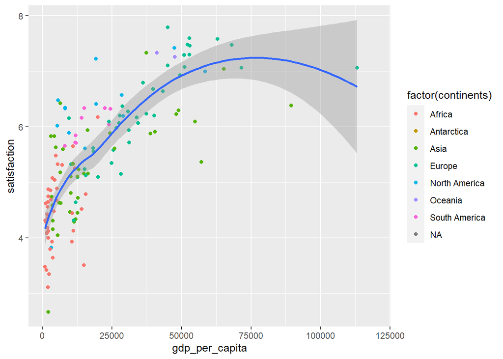

```r
library(owidR)
library(ggplot2)
library(dplyr)
gdp_happiness <- owid("gdp-vs-happiness")
gdp_happiness %>%
  filter(year == 2015)->gdp_happiness_2015
gdp_happiness_2015<-rename(gdp_happiness_2015, gdp_per_capita = 'GDP per capita')
gdp_happiness_2015<-rename(gdp_happiness_2015, satisfaction = 'Life satisfaction in Cantril Ladder (World Happiness Report 2022)')
gdp_happiness_2015<-rename(gdp_happiness_2015, continents = 'Countries Continents')
gdp_happiness_2015$continents<-as.factor(gdp_happiness_2015$continents)
ggplot(gdp_happiness_2015,aes(x=gdp_per_capita, y=satisfaction)) +
  geom_point(aes(color = factor(continents)))+
  geom_smooth(method = "loess")
```

## 5.1.2 Familie og kjønn

- Tenk på følgende spørsmål:
  - Hvordan deles forbruket i familien? Hvordan skal den deles?
  - Hvordan skal inntektene til mann og kone beskattes?
  - Hvor mye bør skatter, nåværende inntekter og fremtidige inntekter oppmuntre mødre med små barn til å akseptere betalt arbeid eller fraråde dem å gjøre det?
  - Bør skatter og ytelser utformes for å oppmuntre til ekteskap? I så fall, hvor sterkt?

Det er klart at ingen av disse spørsmålene har et entydig svar.

## Ytterligere komplikasjoner

- Disse saker er kompliserte fordi det ofte ikke er klart om et bestemt utfall (for eksempel en kvinne som gir opp betalt arbeid for å ta vare på små barn) er et resultat av valg eller av begrensning
- Kjønnsaspekter er av grunnleggende betydning, og det er ofte mulig å diagnostisere dårlig politikk. Men det finnes ikke - og kan ikke finnes - én optimal politikk som fungerer for alle land

## 5.1.3 Sosial velferd

- Velferdsfunksjonen viser sammenhengen mellom samlet velferd og individets velferd
  $$W=W(U^1(y^1),U^2(y^2),...,U^n(y^n))$$
  eller

  $$W=W(y^1,y^2,...,y^n)$$
- Den kan ha forskjellige egenskaper:
  - ikke-synkende
  - symmetrisk
  - additiv
  - konkav
  - konstant relativ ulikhetsaversjon

## 5.2 Fattigdom

## Problemer med å definere fattigdom

- Absolutt eller relativ?
- Absolutt fattigdom: å ikke være i stand til å dekke fysiske primærbehov som nok mat, klær og bolig
- Relativ fattigdom: man har ikke nok midler til å delta fullt ut i det samfunnet man lever i
- Hvem sin inntekt?
- individ, familie, husstand?
- Over hvilken tidsperiode?

## Problemer med å måle fattigdom

- Inntekt er en mangelfull målestokk for velferd
- De forskjellige dimensjonene av fattigdom:
  - Hvor mange fattige (antall individer)?
  - Hvor mye fattigdom (fattigdomsgapet)?
  - Hvor lenge (fattigdomsdynamikk)?
  - Dataproblemer

## Følgende faktorer fører til at flere blir regnet som fattige

- En høyere fattigdomsgrense
- En smalere definisjon av inntekt (f.eks. unntatt hjemmedyrkede råvarer)
- En smalere definisjon av inntektsenheten (f.eks. unntatt inntektene til den utvidede familien)
- En større justering for husholdningsstørrelsen
- Kortere tidsperiode som inntekt måles over

Dermed kan land A ha mindre målt fattigdom enn B på grunn av

- forskjeller i fordelingen av inntekter (før overføringer), eller
- mer sjenerøse overføringer, eller
- fattigdom og ulikhet måles forskjellig (dvs. forskjellen kan være en statistisk artefakt)

## 5.3 Ulikhet 1: Enkeltpersoner og familier

# 5.3.1 Definere likhet og ulikhet

- Folk kan være ulike av to svært forskjellige grunner:
  - Hvis inntektene er forskjellige på grunn av manglende lik tilgang, for eksempel til utdanning, pga. diskriminering, er “samfunnet” urettferdig, og passende tiltak kan innebære å endre strukturer i samfunnet
  - Ulikhet kan oppstå også på grunn av tilfeldige forskjeller i flaks (dvs. “livet” kan være urettferdig)
    - uflaks kan kreve avhjelpende tiltak, men innebærer ikke at samfunnet er urettferdig

## 5.3.2 Måling av ulikhet mellom individer

- Forklaringer for inntektsforskjeller
  - Ulikhet i valg:
    - forskjellige preferanser for pengeinntekt
    - forskjeller i tilegnede ferdigheter
  - Alder
  - Variasjon fra år til år
- Bidrar til inntektsforskjeller
  - Forskjeller i familiestørrelse
  - Ulike priser

## Tolkningen av forskjeller i fordelingen av ytelser

- Anta at en “rik” person mottar ytelse $B_R$, som er større enn en “fattig” person sin ytelse $B_P$
- Er dette et problem?
  - Konsumglatting: $B_R/B_P \ge 1$ kan være riktig
  - Fattigdomsbekjempelse: $B_R/B_P$ bør være $\le 1$.
  - Sosial samhold: $B_R/B_P$ bør være nær $1$.

## Ulikhet 2: Aggregerte målinger

## Den beskrivende tilnærmingen

- Frekvensfordelingen og tilhørende mål
- Lorenz-kurven
  - en grafisk fremstilling av ulikheten i inntektsfordelingen som eksisterer i et bestemt territorium
- Gini-koeffisienten
  - et statistisk mål for statistisk spredning, oppkalt etter den italienske statistikeren Corrado Gini
  - brukes til beregning av inntektsforskjeller eller formuesforskjeller i en befolkning
  - angis som en tallverdi fra 0 til 1, hvor 0 indikerer at alle innbyggerne har akkurat like stor inntekt eller formue, mens tallverdien 1 indikerer at én person eier all inntekt eller formue.
  - mye brukt og nyttig under mange omstendigheter
  - ikke et definitivt mål på ulikhet

# Lorenz-kurven viser prosent av inntekten som går til de x% med lavest inntekt.

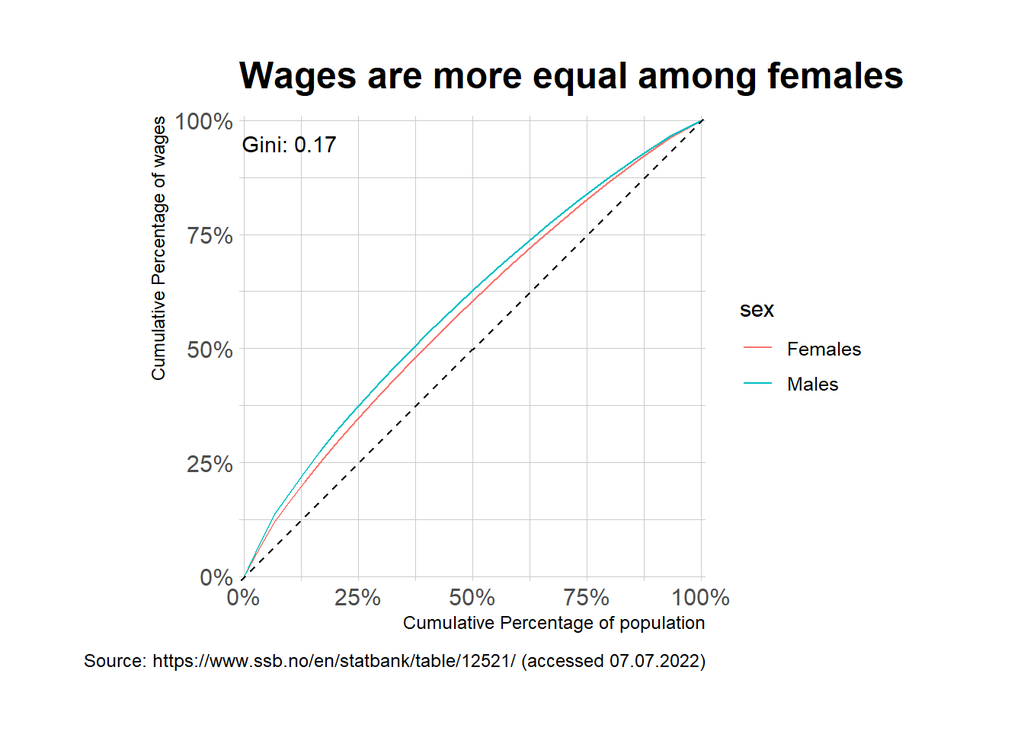

```r
library(PxWebApiData)
data <- ApiData("https://data.ssb.no/api/v0/en/table/12521/",
                Kjonn=c("1","2"),
                Tid ="2021", # Define year to 2021
                Desiler=c("01", "02", "03" ,"04", "05", "06" ,"07", "08" ,"09", "10"),
                ContentsCode="Manedslonn")
data <- data[[1]] # Extract the first list element, which contains full variable names.
library(hrbrthemes)
library(gglorenz)
data %>%
  #filter(Industry %in% c("Technology", "Real Estate")) %>%
  ggplot(aes(x = value, colour = sex)) +
  stat_lorenz(desc = TRUE) +
  coord_fixed() +
  geom_abline(linetype = "dashed") +
  theme_minimal() +
  hrbrthemes::scale_x_percent() +
  hrbrthemes::scale_y_percent() +
  hrbrthemes::theme_ipsum_rc() +
  labs(x = "Cumulative Percentage of population",
       y = "Cumulative Percentage of wages",
       title = "Wages are more equal among females",
       caption = "Source: https://www.ssb.no/en/statbank/table/12521/ (accessed 07.07.2022)")+
  annotate_ineq(data$value)
```

## 5.4.2 Ulikhetsmål basert på en velferdsfunksjon

- Atkinson-teoremet
- Atkinsons ulikhetsmål

## 5.4.3 måling av ulikhet

- Problemer med empirisk arbeid med inntektsfordeling:
  - nesten alle studier er basert på nåværende pengeinntekt
  - oppsummeringen av ulikhet reiser konseptuelle problemer
  - det er store dataproblemer
- Fraværet av et endelig mål på ulikhet betyr ikke at empirisk arbeid er ubrukelig, bare at det skal tolkes med de nødvendige forbeholdene

## 5.5 Konklusjon

- Det finnes ikke noe vitenskapelig “korrekt” mål på fattigdom eller ulikhet
- Måling av fattigdom og ulikhet innebærer uunngåelige verdivurderinger
- Dette betyr ikke at det ikke finnes fattigdom, bare at tall må tolkes med stor forsiktighet